# RAMP/COPING treatment paper core notebook

K L Purves

06 October, 2021

This workbook runs code and shows results for the manuscript *Access and uptake of mental health services during the COVID-19 pandemic: rates, barriers and usefulness*.

# Project description

#### Research questions

1. What are the rates for treatment seeking for MH concerns at each time point (wave)
- rates over time

#### Details, discussion and questions

How do we show change over time in treatment seeking and receipt over time? - are services overwhelmed?

#### Predictors

We select predictors that predict worse outcomes for common mental health problems in this sample [see GitHub for relevant paper here](https://github.com/klpurves/PANCHANGE_analysis/tree/forest_plots)

#### submission

Will submit to Psychological Medicine in first instance

#### variables that need creating

- did you seek treatment at any time

#### Variable categorisation

**treatment type:** supported (requires contact) or self guided ()

Categorisation makes sense for resource allocation etc.

**reasons for seeking** new or existing crisis as a third (number dependent)

**barriers** Systemic and client level

#### People who have helped along the way

Henry Laura Molly

#### Figures

1. COVID figures, lockdown dates, histogram/density
2. Bar plot
3. Map of the UK showing rates of treatment seeking and receipt per area (prop sought treatment == size, proportion received == colour) probably district or rgion level?
4. Forest plots

** prevention figure: bars for each barrier type, coloured by whether systemic or client led

# set up

Clear global environment

```r
remove(list = ls())
```

#### Call in set up scripts

[output not shown]

```
## lfactors v1.0.4
```

[output not shown]

Retrieve the current date to use it for file endings to not overwrite files when one exports files

#### R functions

[output not shown]

# Colour palettes

Define colours for plotting this are the standard coping colours

Choose in this chunk which palette to use 04.07.2020 - Default to 2 colour COPING palette

# ggplot theme

Set up ggplot theme for the plots

# Data wrangling

#### Data import

RAMP

COPING Note, external data reference is a hash-id for coping. So it is consistent across participants and matches, but is not linkable to GLAD ID

# Get age,gender & ethnicity for GLAD, EDGI & NBR

## GLAD

### make age categorical

Age cats:

-77: Seen but not answered 16-18 19-25 26-35 36-45 46-55 56-65 66-70 71-75 76-80 81-85 86-90 91-100 100+

## EDGI

### make age categorical

Age cats:

-77: Seen but not answered 16-18 19-25 26-35 36-45 46-55 56-65 66-70 71-75 76-80 81-85 86-90 91-100 100+

## NBR

### make age categorical

Age cats:

-77: Seen but not answered 16-18 19-25 26-35 36-45 46-55 56-65 66-70 71-75 76-80 81-85 86-90 91-100 100+

### Map ethnicity categories

-99: prefer not to say -88: Dont know -77: Seen but not answered

White Mixed or multiple ethnicities Asian or Asian british Black or Black british Arab Other

### clean gender other column from blank to labelled

#### Create a wave columns in treatment data

Base this on dates of the follow ups drawn from qualtrics.

RAMP 5 waves

1 - May 2020 2 - June 2020 3 - July 2020 (start date actually the last day of June) 4 - September 2020 5 - November 2020

COPING

#### drop data before data collection started

Drop Any data collected earleir than June (our first instance of the questionnaire)

#### select only relevant demographics

Clean postcode to keep only outcode for COPING

Add postcode to COPING

```
Joining, by = "ID"
Joining, by = "ID"
Joining, by = "ID"
```

#### Add extra demographic variables

#### add sample columns

# Demographics cleaning

## clean age (RAMP)

Age cats:

-77: Seen but not answered 1: 16-18 2: 19-25 3: 26-35 4: 36-45 5: 46-55 6: 56-65 7: 66-70 8: 71-75 9: 76-80 10: 81-85 11: 86-90 12: 91-100 13: 100+

## Join RAMP, GLAD and EDGI

## clean ethnicity

Ethnicity:

-99: prefer not to say -88: Dont know -77: Seen but not answered 1: White 2: Mixed or multiple ethnicities 3: Asian or Asian british 4: Black or Black british 5: Arab 6 :Other

## clean gender

Gender cats:

-99: prefer not to say -88: Dont know -77: Seen but not answered 0: Male 1: female 3: Non-binary 4: prefer to self define

#### merge demographics with NBR

#### get gender columns to add to treatment

# mental health diagnosis cleaning

rename id columns so they all match

## Identify subset of diagnoses we have for all datasets.

This includes the full range of MH questions we asked in RAMP

Rename EDGI colums to make sure we can compare

# CLEAN ALL REMAINING MISMATCHING VARIABLES

find intersect with edgi columns

this shows that the only ones not common are eating disorder categories. makes sense as EDGI is ascertained on the basis of having one. So if we collapse across eating disorders we can assume that all edgi fall into this. Will add EDGI last to achieve this.

### select the appropriate columns and merge samples

EDGI all have eating disorders (ascertained for this)

adjust common col list for EDGI

Merge EDGI onto rest

drop start and end date (don't need it as we just need a single point per person)

# Rename the treatment variables and drop irrelevant ones

used the [data dictionary](https://docs.google.com/spreadsheets/d/1Vp028XLxbcXeOdjeuI-3y-kVenKWDR4hW9iJ1tHpttI/edit#gid=1527211037) to identify the relevant items and rename them

#### merge RAMP and COPING treatment data

Use rbind to add COPING to RAMP

#### order wave variable

#### Drop June and January timepoints

#### Drop accidental duplicate IDs

these are IDS that were allocated twice by qualtrics. Technical errors. Will drop all instances (we lose 80 IDs doing this)

```
Warning: Unknown or uninitialised column: `June 2020`.
```

Now drop from our treatment data

#### make seen but not responded NA

#### Create summary variables for treatment

Grouping variables to make sensible categories for comparing different aspects of treatment seeking

##### Sought help for new or pre-existing MH disorder

Categorise reasons for help seeking into whether it was for a pre-existing, newly emerging MH disorder or a crisis

##### Type of treatment (supported / self guided)

Categorise places where treatment was sought into supported or self-guided

make Prefer not to say (-77) NA

create a variable that will say if they sought supported or self guided for each support instance

creat variable counting number of self guided or supported treatment types sought per wave per person

##### received treatment if sought

identify if treatment was received when sought according to category

##### number of agencies from which treatment was received, if sought

##### Sought treatment at any time (How many times, how many total responses)

Create a dataset and column that identifies how many times someone sought help, how many times they responded, and if they ever sought help

Making a new dataset where the count by ID is tracked

##### Reason not sought

##### Client level vs systemic barriers

identify if treatment was received when sought according to category

Identify whether barriers are systemic or client-level

#### group agencies for help prevention into client-led or supported

creates PreventHelp_Supported and PreventHelp_SelfGuided columns

### helpfulness

#### Relabel factors

#### group agencies for helpfulness into client led or supported.

Assess helpfulness for both type seperately depending on helpfulness by agency sought

# Analyses

## Descriptives

### Demographics

Age, ethnicity and gender for those who have responded to at least 1 wave of the treatment survey, dropping duplicates as per treat_dt step

#### check numbers

##### Ethnicity

```
Frequencies
dem$Ethnicity
Type: Factor

                                       Freq    % Valid   % Valid Cum.    % Total   % Total Cum.
----------------------------------- ------- ---------- -------------- ---------- --------------
                  Prefer not to say      33     0.1394         0.1394     0.1274         0.1274
                         Don't know       6     0.0254         0.1648     0.0232         0.1506
                    Did not respond       1     0.0042         0.1690     0.0039         0.1545
                              White   22711    95.9566        96.1256    87.7076        87.8621
      Mixed or multiple ethnicities     332     1.4027        97.5283     1.2822        89.1442
             Asian or Asian British     220     0.9295        98.4578     0.8496        89.9938
             Black or Black British      96     0.4056        98.8634     0.3707        90.3646
                               Arab       9     0.0380        98.9015     0.0348        90.3993
                              Other     157     0.6633        99.5648     0.6063        91.0056
              Seen but not answered     103     0.4352       100.0000     0.3978        91.4034
                               <NA>    2226                               8.5966       100.0000
                              Total   25894   100.0000       100.0000   100.0000       100.0000
```

By sample

```
Frequencies
dem$Ethnicity
Type: Factor
Group: Sample = COPING

                                       Freq   % Valid   % Valid Cum.   % Total   % Total Cum.
----------------------------------- ------- --------- -------------- --------- --------------
                  Prefer not to say      13     0.072          0.072     0.064          0.064
                         Don't know       4     0.022          0.094     0.020          0.084
                    Did not respond       0     0.000          0.094     0.000          0.084
                              White   17424    96.276         96.370    85.740         85.823
      Mixed or multiple ethnicities     228     1.260         97.630     1.122         86.945
             Asian or Asian British     146     0.807         98.436     0.718         87.664
             Black or Black British      59     0.326         98.762     0.290         87.954
                               Arab       3     0.017         98.779     0.015         87.969
                              Other     118     0.652         99.431     0.581         88.549
              Seen but not answered     103     0.569        100.000     0.507         89.056
                               <NA>    2224                             10.944        100.000
                              Total   20322   100.000        100.000   100.000        100.000

Group: Sample = RAMP

                                      Freq   % Valid   % Valid Cum.   % Total   % Total Cum.
----------------------------------- ------ --------- -------------- --------- --------------
                  Prefer not to say     20     0.359          0.359     0.359          0.359
                         Don't know      2     0.036          0.395     0.036          0.395
                    Did not respond      1     0.018          0.413     0.018          0.413
                              White   5287    94.919         95.332    94.885         95.298
      Mixed or multiple ethnicities    104     1.867         97.199     1.866         97.164
             Asian or Asian British     74     1.329         98.528     1.328         98.492
             Black or Black British     37     0.664         99.192     0.664         99.156
                               Arab      6     0.108         99.300     0.108         99.264
                              Other     39     0.700        100.000     0.700         99.964
              Seen but not answered      0     0.000        100.000     0.000         99.964
                               <NA>      2                              0.036        100.000
                              Total   5572   100.000        100.000   100.000        100.000
```

##### Gender

```
Frequencies
dem$Gender
Type: Factor

                               Freq   % Valid   % Valid Cum.   % Total   % Total Cum.
--------------------------- ------- --------- -------------- --------- --------------
          Prefer not to say      26     0.101          0.101     0.100          0.100
                 Don't know      43     0.166          0.267     0.166          0.266
            Did not respond      11     0.043          0.309     0.042          0.309
                       Male    7635    29.516         29.826    29.486         29.795
                     Female   17910    69.239         99.064    69.167         98.961
                 Non-binary     204     0.789         99.853     0.788         99.749
      Prefer to self define      38     0.147        100.000     0.147         99.896
                       <NA>      27                              0.104        100.000
                      Total   25894   100.000        100.000   100.000        100.000
```

By sample

```
Frequencies
dem$Gender
Type: Factor
Group: Sample = COPING

                               Freq   % Valid   % Valid Cum.   % Total   % Total Cum.
--------------------------- ------- --------- -------------- --------- --------------
          Prefer not to say      16     0.079          0.079     0.079          0.079
                 Don't know      32     0.158          0.236     0.157          0.236
            Did not respond      10     0.049          0.286     0.049          0.285
                       Male    6500    32.024         32.310    31.985         32.270
                     Female   13545    66.734         99.044    66.652         98.922
                 Non-binary     164     0.808         99.852     0.807         99.729
      Prefer to self define      30     0.148        100.000     0.148         99.877
                       <NA>      25                              0.123        100.000
                      Total   20322   100.000        100.000   100.000        100.000

Group: Sample = RAMP

                              Freq   % Valid   % Valid Cum.   % Total   % Total Cum.
--------------------------- ------ --------- -------------- --------- --------------
          Prefer not to say     10     0.180          0.180     0.179          0.179
                 Don't know     11     0.197          0.377     0.197          0.377
            Did not respond      1     0.018          0.395     0.018          0.395
                       Male   1135    20.377         20.772    20.370         20.765
                     Female   4365    78.366         99.138    78.338         99.103
                 Non-binary     40     0.718         99.856     0.718         99.821
      Prefer to self define      8     0.144        100.000     0.144         99.964
                       <NA>      2                              0.036        100.000
                      Total   5572   100.000        100.000   100.000        100.000
```

##### Age (all brackets)

```
Frequencies
dem$AgeAll
Type: Factor

                         Freq    % Valid   % Valid Cum.    % Total   % Total Cum.
--------------------- ------- ---------- -------------- ---------- --------------
      Did not respond       0     0.0000         0.0000     0.0000         0.0000
                16-18     384     2.1368         2.1368     1.4830         1.4830
                19-25    1186     6.5995         8.7363     4.5802         6.0632
                26-35    2481    13.8056        22.5419     9.5814        15.6446
                36-45    2549    14.1840        36.7258     9.8440        25.4885
                46-55    3928    21.8574        58.5833    15.1695        40.6581
                56-65    4508    25.0849        83.6681    17.4094        58.0675
                66-70    1561     8.6862        92.3543     6.0284        64.0959
                71-75    1001     5.5701        97.9244     3.8658        67.9617
                76-80     291     1.6193        99.5437     1.1238        69.0855
                81-85      67     0.3728        99.9165     0.2587        69.3442
                86-90      11     0.0612        99.9777     0.0425        69.3867
               91-100       2     0.0111        99.9889     0.0077        69.3945
                 100+       2     0.0111       100.0000     0.0077        69.4022
                 <NA>    7923                              30.5978       100.0000
                Total   25894   100.0000       100.0000   100.0000       100.0000
```

By sample

```
Frequencies
dem$AgeAll
Type: Factor
Group: Sample = COPING

                         Freq    % Valid   % Valid Cum.    % Total   % Total Cum.
--------------------- ------- ---------- -------------- ---------- --------------
      Did not respond       0     0.0000         0.0000     0.0000         0.0000
                16-18     166     1.3386         1.3386     0.8168         0.8168
                19-25     850     6.8543         8.1929     4.1827         4.9995
                26-35    1924    15.5149        23.7078     9.4676        14.4671
                36-45    2035    16.4100        40.1177    10.0138        24.4809
                46-55    2876    23.1917        63.3094    14.1522        38.6330
                56-65    2839    22.8933        86.2027    13.9701        52.6031
                66-70     919     7.4107        93.6134     4.5222        57.1253
                71-75     586     4.7254        98.3388     2.8836        60.0089
                76-80     167     1.3467        99.6855     0.8218        60.8306
                81-85      38     0.3064        99.9919     0.1870        61.0176
                86-90       1     0.0081       100.0000     0.0049        61.0225
               91-100       0     0.0000       100.0000     0.0000        61.0225
                 100+       0     0.0000       100.0000     0.0000        61.0225
                 <NA>    7921                              38.9775       100.0000
                Total   20322   100.0000       100.0000   100.0000       100.0000

Group: Sample = RAMP

                        Freq   % Valid   % Valid Cum.   % Total   % Total Cum.
--------------------- ------ --------- -------------- --------- --------------
      Did not respond      0     0.000          0.000     0.000          0.000
                16-18    218     3.914          3.914     3.912          3.912
                19-25    336     6.032          9.946     6.030          9.943
                26-35    557    10.000         19.946     9.996         19.939
                36-45    514     9.228         29.174     9.225         29.164
                46-55   1052    18.887         48.061    18.880         48.044
                56-65   1669    29.964         78.025    29.953         77.997
                66-70    642    11.526         89.551    11.522         89.519
                71-75    415     7.451         97.002     7.448         96.967
                76-80    124     2.226         99.228     2.225         99.192
                81-85     29     0.521         99.749     0.520         99.713
                86-90     10     0.180         99.928     0.179         99.892
               91-100      2     0.036         99.964     0.036         99.928
                 100+      2     0.036        100.000     0.036         99.964
                 <NA>      2                              0.036        100.000
                Total   5572   100.000        100.000   100.000        100.000
```

##### Age (81+ collapses)

```
Frequencies
dem$Age80up
Type: Factor

                         Freq   % Valid   % Valid Cum.   % Total   % Total Cum.
--------------------- ------- --------- -------------- --------- --------------
      Did not respond       0      0.00           0.00      0.00           0.00
                16-18     384      2.14           2.14      1.48           1.48
                19-25    1186      6.60           8.74      4.58           6.06
                26-35    2481     13.81          22.54      9.58          15.64
                36-45    2549     14.18          36.73      9.84          25.49
                46-55    3928     21.86          58.58     15.17          40.66
                56-65    4508     25.08          83.67     17.41          58.07
                66-70    1561      8.69          92.35      6.03          64.10
                71-75    1001      5.57          97.92      3.87          67.96
                76-80     291      1.62          99.54      1.12          69.09
                  81+      82      0.46         100.00      0.32          69.40
                 <NA>    7923                              30.60         100.00
                Total   25894    100.00         100.00    100.00         100.00
```

By sample

```
Frequencies
dem$Age80up
Type: Factor
Group: Sample = COPING

                         Freq   % Valid   % Valid Cum.   % Total   % Total Cum.
--------------------- ------- --------- -------------- --------- --------------
      Did not respond       0      0.00           0.00      0.00           0.00
                16-18     166      1.34           1.34      0.82           0.82
                19-25     850      6.85           8.19      4.18           5.00
                26-35    1924     15.51          23.71      9.47          14.47
                36-45    2035     16.41          40.12     10.01          24.48
                46-55    2876     23.19          63.31     14.15          38.63
                56-65    2839     22.89          86.20     13.97          52.60
                66-70     919      7.41          93.61      4.52          57.13
                71-75     586      4.73          98.34      2.88          60.01
                76-80     167      1.35          99.69      0.82          60.83
                  81+      39      0.31         100.00      0.19          61.02
                 <NA>    7921                              38.98         100.00
                Total   20322    100.00         100.00    100.00         100.00

Group: Sample = RAMP

                        Freq   % Valid   % Valid Cum.   % Total   % Total Cum.
--------------------- ------ --------- -------------- --------- --------------
      Did not respond      0     0.000          0.000     0.000          0.000
                16-18    218     3.914          3.914     3.912          3.912
                19-25    336     6.032          9.946     6.030          9.943
                26-35    557    10.000         19.946     9.996         19.939
                36-45    514     9.228         29.174     9.225         29.164
                46-55   1052    18.887         48.061    18.880         48.044
                56-65   1669    29.964         78.025    29.953         77.997
                66-70    642    11.526         89.551    11.522         89.519
                71-75    415     7.451         97.002     7.448         96.967
                76-80    124     2.226         99.228     2.225         99.192
                  81+     43     0.772        100.000     0.772         99.964
                 <NA>      2                              0.036        100.000
                Total   5572   100.000        100.000   100.000        100.000
```

### Mental health diagnoses

Clean so we match treatment data and dont have duplicates

List of diagnosis columns

#### everyone

frequencies for all diagnoses

```
Frequencies
MH$mhd.depressive_disorder
Type: Numeric

               Freq   % Valid   % Valid Cum.   % Total   % Total Cum.
----------- ------- --------- -------------- --------- --------------
          1   13023    100.00         100.00     50.10          50.10
       <NA>   12969                              49.90         100.00
      Total   25992    100.00         100.00    100.00         100.00
Frequencies
MH$mhd.anxiety_disorder
Type: Numeric

               Freq   % Valid   % Valid Cum.   % Total   % Total Cum.
----------- ------- --------- -------------- --------- --------------
          1   10513    100.00         100.00     40.45          40.45
       <NA>   15479                              59.55         100.00
      Total   25992    100.00         100.00    100.00         100.00
Frequencies
MH$mhd.ptsd
Type: Numeric

               Freq   % Valid   % Valid Cum.   % Total   % Total Cum.
----------- ------- --------- -------------- --------- --------------
        -77      44     0.169          0.169     0.169          0.169
          0   23846    91.782         91.952    91.744         91.913
          1    2091     8.048        100.000     8.045         99.958
       <NA>      11                              0.042        100.000
      Total   25992   100.000        100.000   100.000        100.000
Frequencies
MH$mhd.ocrd
Type: Numeric

               Freq   % Valid   % Valid Cum.   % Total   % Total Cum.
----------- ------- --------- -------------- --------- --------------
          1    2003    100.00         100.00      7.71           7.71
       <NA>   23989                              92.29         100.00
      Total   25992    100.00         100.00    100.00         100.00
Frequencies
MH$mhd.eating_disorder
Type: Numeric

               Freq   % Valid   % Valid Cum.   % Total   % Total Cum.
----------- ------- --------- -------------- --------- --------------
          1    1580    100.00         100.00      6.08           6.08
       <NA>   24412                              93.92         100.00
      Total   25992    100.00         100.00    100.00         100.00
Frequencies
MH$mhd.mania_hypomania_bipolar_or_manicdepression
Type: Numeric

               Freq   % Valid   % Valid Cum.   % Total   % Total Cum.
----------- ------- --------- -------------- --------- --------------
        -77      44     0.169          0.169     0.169          0.169
          0   25083    96.544         96.713    96.503         96.672
          1     854     3.287        100.000     3.286         99.958
       <NA>      11                              0.042        100.000
      Total   25992   100.000        100.000   100.000        100.000
Frequencies
MH$mhd.psychotic_disorder
Type: Numeric

               Freq   % Valid   % Valid Cum.   % Total   % Total Cum.
----------- ------- --------- -------------- --------- --------------
          1     443    100.00         100.00      1.70           1.70
       <NA>   25549                              98.30         100.00
      Total   25992    100.00         100.00    100.00         100.00
Frequencies
MH$mhd.personality_disorder
Type: Numeric

               Freq   % Valid   % Valid Cum.   % Total   % Total Cum.
----------- ------- --------- -------------- --------- --------------
        -77     453     1.744          1.744     1.743          1.743
          0   24605    94.704         96.447    94.664         96.407
          1     923     3.553        100.000     3.551         99.958
       <NA>      11                              0.042        100.000
      Total   25992   100.000        100.000   100.000        100.000
Frequencies
MH$mhd.autism_spectrum_disorder_asd
Type: Numeric

               Freq   % Valid   % Valid Cum.   % Total   % Total Cum.
----------- ------- --------- -------------- --------- --------------
        -77     453     1.744          1.744     1.743          1.743
          0   25100    96.609         98.353    96.568         98.311
          1     428     1.647        100.000     1.647         99.958
       <NA>      11                              0.042        100.000
      Total   25992   100.000        100.000   100.000        100.000
Frequencies
MH$mhd.attention_deficit_hyperactivity_disorder
Type: Numeric

               Freq   % Valid   % Valid Cum.   % Total   % Total Cum.
----------- ------- --------- -------------- --------- --------------
        -77     453     1.744          1.744     1.743          1.743
          0   25306    97.402         99.146    97.361         99.104
          1     222     0.854        100.000     0.854         99.958
       <NA>      11                              0.042        100.000
      Total   25992   100.000        100.000   100.000        100.000
```

#### By sample

frequencies for all diagnoses

```
[1] "mhd.depressive_disorder"
Cross-Tabulation, Row Proportions
MH[, i] * Sample
Data Frame: MH

--------- -------- --------------- -------------- ----------------
            Sample          COPING           RAMP            Total
  MH[, i]
        1            10284 (79.0%)   2739 (21.0%)   13023 (100.0%)
     <NA>            10146 (78.2%)   2823 (21.8%)   12969 (100.0%)
    Total            20430 (78.6%)   5562 (21.4%)   25992 (100.0%)
--------- -------- --------------- -------------- ----------------
[1] "mhd.anxiety_disorder"
Cross-Tabulation, Row Proportions
MH[, i] * Sample
Data Frame: MH

--------- -------- --------------- -------------- ----------------
            Sample          COPING           RAMP            Total
  MH[, i]
        1             8257 (78.5%)   2256 (21.5%)   10513 (100.0%)
     <NA>            12173 (78.6%)   3306 (21.4%)   15479 (100.0%)
    Total            20430 (78.6%)   5562 (21.4%)   25992 (100.0%)
--------- -------- --------------- -------------- ----------------
[1] "mhd.ptsd"
Cross-Tabulation, Row Proportions
MH[, i] * Sample
Data Frame: MH

--------- -------- --------------- -------------- ----------------
            Sample          COPING           RAMP            Total
  MH[, i]
      -77               38 (86.4%)      6 (13.6%)      44 (100.0%)
        0            18748 (78.6%)   5098 (21.4%)   23846 (100.0%)
        1             1635 (78.2%)    456 (21.8%)    2091 (100.0%)
     <NA>                9 (81.8%)      2 (18.2%)      11 (100.0%)
    Total            20430 (78.6%)   5562 (21.4%)   25992 (100.0%)
--------- -------- --------------- -------------- ----------------
[1] "mhd.ocrd"
Cross-Tabulation, Row Proportions
```

[output cut: 75 more lines]

```
--------- -------- --------------- -------------- ----------------
[1] "mhd.attention_deficit_hyperactivity_disorder"
Cross-Tabulation, Row Proportions
MH[, i] * Sample
Data Frame: MH

--------- -------- --------------- -------------- ----------------
            Sample          COPING           RAMP            Total
  MH[, i]
      -77              103 (22.7%)    350 (77.3%)     453 (100.0%)
        0            20147 (79.6%)   5159 (20.4%)   25306 (100.0%)
        1              171 (77.0%)     51 (23.0%)     222 (100.0%)
     <NA>                9 (81.8%)      2 (18.2%)      11 (100.0%)
    Total            20430 (78.6%)   5562 (21.4%)   25992 (100.0%)
--------- -------- --------------- -------------- ----------------
```

## treat dat

### Response rates per wave

| wave | n |
| --- | --- |
| July 2020 | 21036 |
| August 2020 | 18929 |
| September 2020 | 4915 |
| October 2020 | 15289 |
| November 2020 | 4823 |
| December 2020 | 14487 |

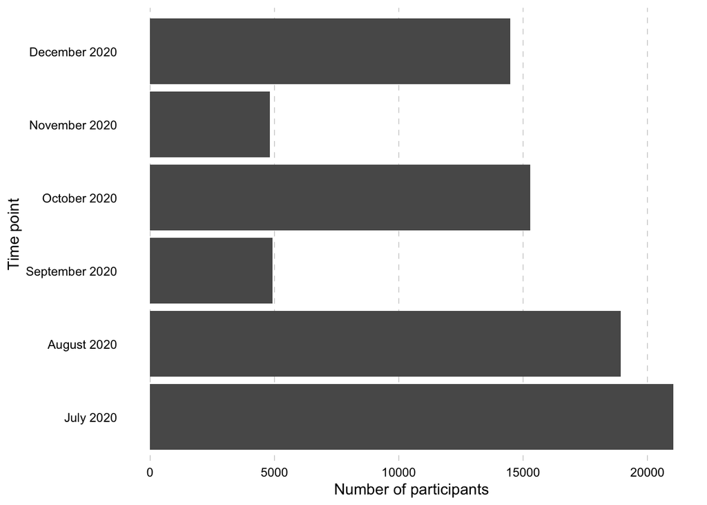

By sample

### *Plot sample size*

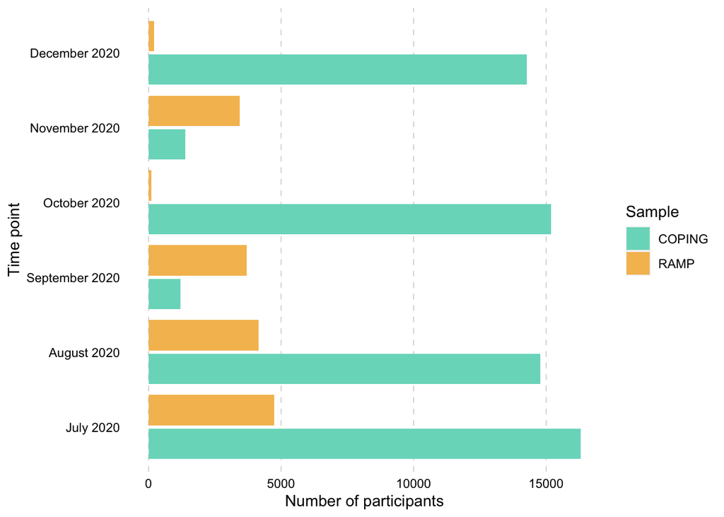

### Frequency of treatment seeking per wave

| wave | 0 | 1 | NA | total_responders | prop_responders |
| --- | --- | --- | --- | --- | --- |
| July 2020 | 3923 | 697 | 16416 | 4620 | 15.08658 |
| August 2020 | 15665 | 2439 | 825 | 18104 | 13.47216 |
| September 2020 | 4010 | 778 | 127 | 4788 | 16.24896 |
| October 2020 | 12759 | 2027 | 503 | 14786 | 13.70891 |
| November 2020 | 3898 | 797 | 128 | 4695 | 16.97551 |
| December 2020 | 12187 | 1769 | 531 | 13956 | 12.67555 |

```
[1] 0.1395757
```

```
[1] 14.69461
```

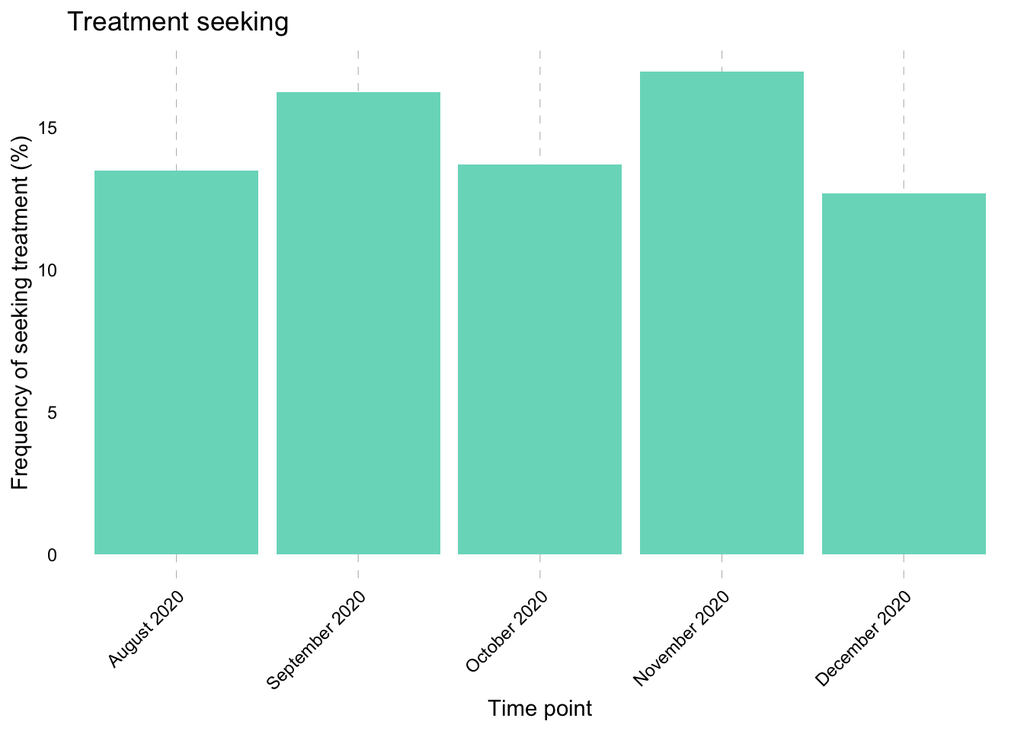

### *Plot treatment gap*

| wave | Received | Not received |
| --- | --- | --- |
| July 2020 | 87.80488 | 12.19512 |
| August 2020 | 83.47683 | 16.52317 |
| September 2020 | 81.87661 | 18.12339 |
| October 2020 | 82.28910 | 17.71090 |
| November 2020 | 81.17942 | 18.82058 |
| December 2020 | 84.28491 | 15.71509 |

```
[1] 16.51471
```

```
[1] 2.393076
```

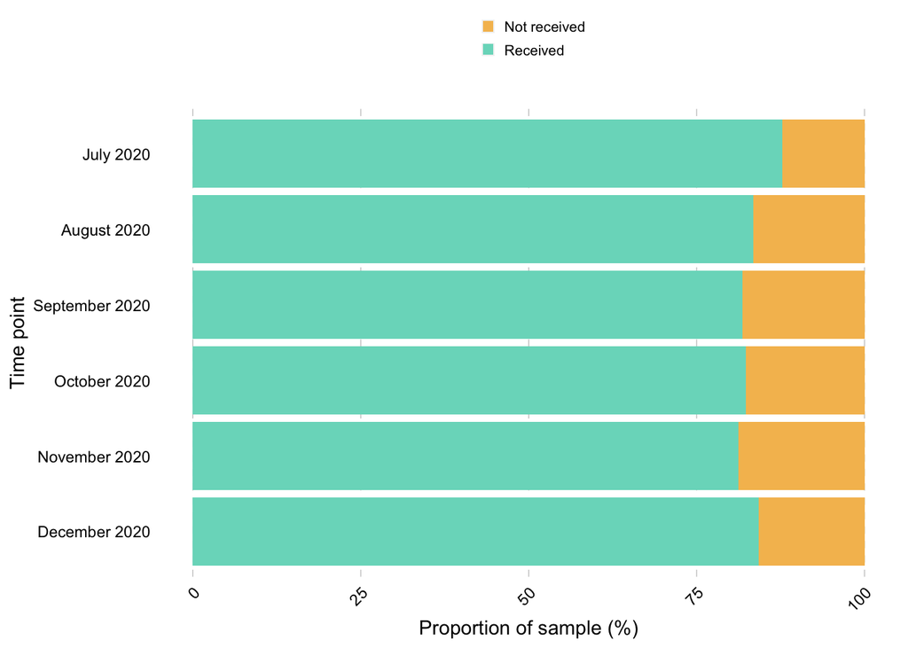

By sample

### Reason for seeking treatment by wave

| wave | Mental health crisis | Newly emerging symptoms | Seeking new treatment | Existing mental health concern |
| --- | --- | --- | --- | --- |
| July 2020 | 1.750000 | 25.87500 | 0.5000000 | 71.87500 |
| August 2020 | 1.146026 | 20.73937 | 0.7024030 | 77.41220 |
| September 2020 | 2.372479 | 22.65718 | 0.4744958 | 74.49585 |
| October 2020 | 1.745748 | 19.69561 | 0.6266786 | 77.93196 |
| November 2020 | 1.520468 | 22.57310 | 0.4678363 | 75.43860 |
| December 2020 | 1.550388 | 20.00000 | 0.6201550 | 77.82946 |

### *Plot reason seek*

| wave | Mental health crisis | Newly emerging symptoms | Seeking new treatment | Existing mental health concern |
| --- | --- | --- | --- | --- |
| July 2020 | 1.750000 | 25.87500 | 0.5000000 | 71.87500 |
| August 2020 | 1.146026 | 20.73937 | 0.7024030 | 77.41220 |
| September 2020 | 2.372479 | 22.65718 | 0.4744958 | 74.49585 |
| October 2020 | 1.745748 | 19.69561 | 0.6266786 | 77.93196 |
| November 2020 | 1.520468 | 22.57310 | 0.4678363 | 75.43860 |
| December 2020 | 1.550388 | 20.00000 | 0.6201550 | 77.82946 |

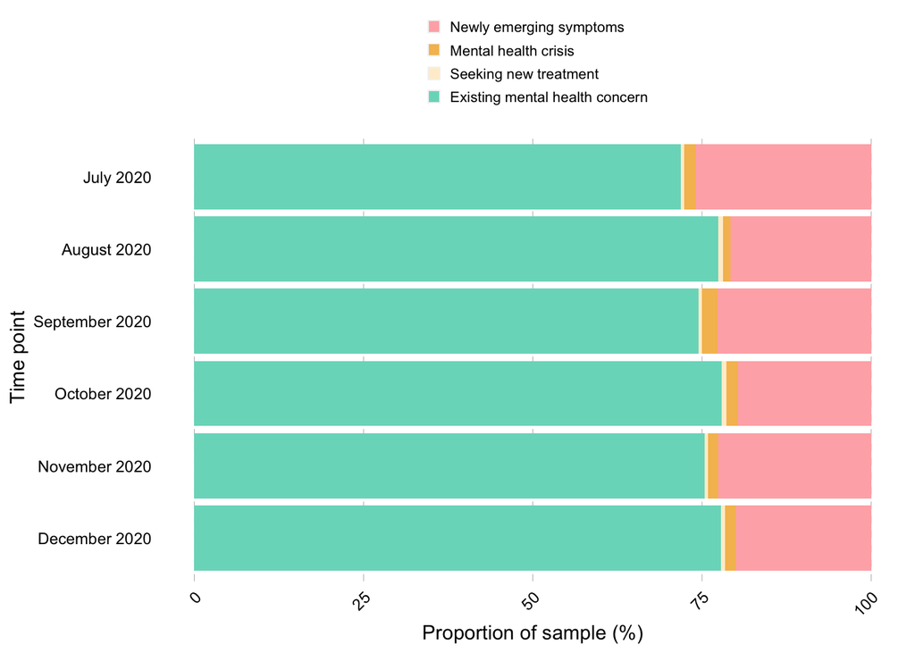

By sample

### *Plot reason not seek*

| reason | category | n | percent |
| --- | --- | --- | --- |
| Feel fine | Mild or no current symptoms | 29626 | 51.769270 |
| Feel better | Mild or no current symptoms | 2061 | 3.601447 |
| Not bad enough | Mild or no current symptoms | 13340 | 23.310675 |
| Don't think help available | Systemic | 2630 | 4.595733 |
| Bad past experience | Systemic | 2196 | 3.837350 |
| Didn't know where to find | Systemic | 1060 | 1.852273 |
| Too busy | Client | 1652 | 2.886749 |
| Want to but haven't | Client | 1584 | 2.767924 |
| Other | Other | 3078 | 5.378580 |

| category | total | percent |
| --- | --- | --- |
| Client | 3236 | 5.654673 |
| Mild or no current symptoms | 45027 | 78.681392 |
| Other | 3078 | 5.378580 |
| Systemic | 5886 | 10.285355 |

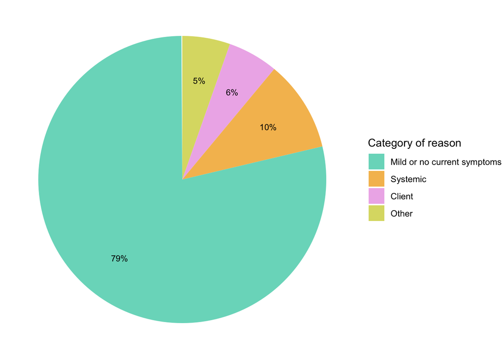

### Frequency of treatment receipt by type and wave (any instances of treatment, not total instances)

Seeking ANY instances of this type of treatment (i.e., if they sought supported help from 3 sources in a wave, it will just register once) BUT they might ALSO have sought help from both routes (i.e., if they sought help from a supported and self guided source, they will register in each of these categories. So we might expect to have more people in the supported + self guided categories per wave than we do who sought help for themselves above)

**Supported**

| wave | Did not seek supported treatment | Sought Supported |
| --- | --- | --- |
| July 2020 | 20454 | 582 |
| August 2020 | 16975 | 1954 |
| September 2020 | 4315 | 600 |
| October 2020 | 13693 | 1596 |
| November 2020 | 4210 | 613 |
| December 2020 | 13077 | 1410 |

By sample

**Self guided**

| wave | Did not seek self-guided treatment | Sought Self-guided |
| --- | --- | --- |
| July 2020 | 20731 | 305 |
| August 2020 | 17925 | 1004 |
| September 2020 | 4614 | 301 |
| October 2020 | 14549 | 740 |
| November 2020 | 4536 | 287 |
| December 2020 | 13799 | 688 |

**COMPARISON of FREQ of support type**

```
[1] 6755
```

```
[1] 67.01389
```

```
[1] 3325
```

```
[1] 32.98611
```

By sample

### Frequency of treatment seeking overall

Number of people who sought treatment at any point during the pandemic

```
Frequencies
treat_dat_byID$AnySeek
Type: Character

                                   Freq   % Valid   % Valid Cum.   % Total   % Total Cum.
------------------------------- ------- --------- -------------- --------- --------------
              Never sought help   20583     79.59          79.59     79.59          79.59
      Sought help at least once    5279     20.41         100.00     20.41         100.00
                           <NA>       0                               0.00         100.00
                          Total   25862    100.00         100.00    100.00         100.00
```

By sample

```
Frequencies
treat_dat_byIDSamp$AnySeek
Type: Character
Group: Sample = COPING

                                   Freq   % Valid   % Valid Cum.   % Total   % Total Cum.
------------------------------- ------- --------- -------------- --------- --------------
              Never sought help   16394     80.68          80.68     80.68          80.68
      Sought help at least once    3927     19.32         100.00     19.32         100.00
                           <NA>       0                               0.00         100.00
                          Total   20321    100.00         100.00    100.00         100.00

Group: Sample = RAMP

                                  Freq   % Valid   % Valid Cum.   % Total   % Total Cum.
------------------------------- ------ --------- -------------- --------- --------------
              Never sought help   4189     75.59          75.59     75.59          75.59
      Sought help at least once   1353     24.41         100.00     24.41         100.00
                           <NA>      0                               0.00         100.00
                          Total   5542    100.00         100.00    100.00         100.00
```

### Count table of treatment seeking across all waves

```
Frequencies
treat_dat_byID$n
Type: Numeric

               Freq    % Valid   % Valid Cum.    % Total   % Total Cum.
----------- ------- ---------- -------------- ---------- --------------
          0   20583    79.5878        79.5878    79.5878        79.5878
          1    3043    11.7663        91.3541    11.7663        91.3541
          2    1400     5.4133        96.7675     5.4133        96.7675
          3     699     2.7028        99.4703     2.7028        99.4703
          4     136     0.5259        99.9961     0.5259        99.9961
         23       1     0.0039       100.0000     0.0039       100.0000
       <NA>       0                               0.0000       100.0000
      Total   25862   100.0000       100.0000   100.0000       100.0000
```

By sample

```
Frequencies
treat_dat_byIDSamp$n
Type: Numeric
Group: Sample = COPING

               Freq    % Valid   % Valid Cum.    % Total   % Total Cum.
----------- ------- ---------- -------------- ---------- --------------
          0   16394    80.6752        80.6752    80.6752        80.6752
          1    2333    11.4807        92.1559    11.4807        92.1559
          2    1064     5.2360        97.3919     5.2360        97.3919
          3     524     2.5786        99.9705     2.5786        99.9705
          4       5     0.0246        99.9951     0.0246        99.9951
         16       1     0.0049       100.0000     0.0049       100.0000
       <NA>       0                               0.0000       100.0000
      Total   20321   100.0000       100.0000   100.0000       100.0000

Group: Sample = RAMP

              Freq   % Valid   % Valid Cum.   % Total   % Total Cum.
----------- ------ --------- -------------- --------- --------------
          0   4189    75.586         75.586    75.586         75.586
          1    710    12.811         88.398    12.811         88.398
          2    336     6.063         94.460     6.063         94.460
          3    175     3.158         97.618     3.158         97.618
          4    131     2.364         99.982     2.364         99.982
          7      1     0.018        100.000     0.018        100.000
       <NA>      0                              0.000        100.000
      Total   5542   100.000        100.000   100.000        100.000
```

### Count of the number of different sources from which treatment was sought, by treatment type, wave

Supported

By sample

Self guided

By sample

### Frequency of treatment receipt by wave (any instances of treatment, not total instances)

Receiving ANY instances of this type of treatment (i.e., if they sought and received supported help from 3 sources in a wave, it will just register once)

Supported

```
Frequencies
treat_dat$TypeReceived.Supported.Any
Type: Character
Group: wave = July 2020

                                             Freq   % Valid   % Valid Cum.   % Total   % Total Cum.
----------------------------------------- ------- --------- -------------- --------- --------------
      Did not receive supported treatment   20477     97.34          97.34     97.34          97.34
                       Received Supported     559      2.66         100.00      2.66         100.00
                                     <NA>       0                               0.00         100.00
                                    Total   21036    100.00         100.00    100.00         100.00

Group: wave = August 2020

                                             Freq   % Valid   % Valid Cum.   % Total   % Total Cum.
----------------------------------------- ------- --------- -------------- --------- --------------
      Did not receive supported treatment   17093     90.30          90.30     90.30          90.30
                       Received Supported    1836      9.70         100.00      9.70         100.00
                                     <NA>       0                               0.00         100.00
                                    Total   18929    100.00         100.00    100.00         100.00

Group: wave = September 2020

                                            Freq   % Valid   % Valid Cum.   % Total   % Total Cum.
----------------------------------------- ------ --------- -------------- --------- --------------
      Did not receive supported treatment   4344     88.38          88.38     88.38          88.38
                       Received Supported    571     11.62         100.00     11.62         100.00
                                     <NA>      0                               0.00         100.00
                                    Total   4915    100.00         100.00    100.00         100.00

Group: wave = October 2020

                                             Freq   % Valid   % Valid Cum.   % Total   % Total Cum.
----------------------------------------- ------- --------- -------------- --------- --------------
      Did not receive supported treatment   13795     90.23          90.23     90.23          90.23
                       Received Supported    1494      9.77         100.00      9.77         100.00
                                     <NA>       0                               0.00         100.00
                                    Total   15289    100.00         100.00    100.00         100.00

Group: wave = November 2020

                                            Freq   % Valid   % Valid Cum.   % Total   % Total Cum.
----------------------------------------- ------ --------- -------------- --------- --------------
      Did not receive supported treatment   4233     87.77          87.77     87.77          87.77
                       Received Supported    590     12.23         100.00     12.23         100.00
                                     <NA>      0                               0.00         100.00
                                    Total   4823    100.00         100.00    100.00         100.00

Group: wave = December 2020

                                             Freq   % Valid   % Valid Cum.   % Total   % Total Cum.
----------------------------------------- ------- --------- -------------- --------- --------------
      Did not receive supported treatment   13138     90.69          90.69     90.69          90.69
                       Received Supported    1349      9.31         100.00      9.31         100.00
                                     <NA>       0                               0.00         100.00
                                    Total   14487    100.00         100.00    100.00         100.00
```

By sample

```
Frequencies
treat_dat$TypeReceived.SelfGuide.Any
Type: Character
Group: wave = July 2020

                                               Freq   % Valid   % Valid Cum.   % Total   % Total Cum.
------------------------------------------- ------- --------- -------------- --------- --------------
      Did not receive self-guided treatment   20789     98.83          98.83     98.83          98.83
                       Received Self-guided     247      1.17         100.00      1.17         100.00
                                       <NA>       0                               0.00         100.00
                                      Total   21036    100.00         100.00    100.00         100.00

Group: wave = August 2020

                                               Freq   % Valid   % Valid Cum.   % Total   % Total Cum.
------------------------------------------- ------- --------- -------------- --------- --------------
      Did not receive self-guided treatment   18105     95.65          95.65     95.65          95.65
                       Received Self-guided     824      4.35         100.00      4.35         100.00
                                       <NA>       0                               0.00         100.00
                                      Total   18929    100.00         100.00    100.00         100.00

Group: wave = September 2020

                                              Freq   % Valid   % Valid Cum.   % Total   % Total Cum.
------------------------------------------- ------ --------- -------------- --------- --------------
      Did not receive self-guided treatment   4661     94.83          94.83     94.83          94.83
                       Received Self-guided    254      5.17         100.00      5.17         100.00
                                       <NA>      0                               0.00         100.00
                                      Total   4915    100.00         100.00    100.00         100.00

Group: wave = October 2020

                                               Freq   % Valid   % Valid Cum.   % Total   % Total Cum.
------------------------------------------- ------- --------- -------------- --------- --------------
      Did not receive self-guided treatment   14640     95.76          95.76     95.76          95.76
                       Received Self-guided     649      4.24         100.00      4.24         100.00
                                       <NA>       0                               0.00         100.00
                                      Total   15289    100.00         100.00    100.00         100.00

Group: wave = November 2020

                                              Freq   % Valid   % Valid Cum.   % Total   % Total Cum.
------------------------------------------- ------ --------- -------------- --------- --------------
      Did not receive self-guided treatment   4592     95.21          95.21     95.21          95.21
                       Received Self-guided    231      4.79         100.00      4.79         100.00
                                       <NA>      0                               0.00         100.00
                                      Total   4823    100.00         100.00    100.00         100.00

Group: wave = December 2020

                                               Freq   % Valid   % Valid Cum.   % Total   % Total Cum.
------------------------------------------- ------- --------- -------------- --------- --------------
      Did not receive self-guided treatment   13903     95.97          95.97     95.97          95.97
                       Received Self-guided     584      4.03         100.00      4.03         100.00
                                       <NA>       0                               0.00         100.00
                                      Total   14487    100.00         100.00    100.00         100.00
```

By sample

### Frequency of treatment receipt by wave (total)

HOW MANY instances of treatment were received

Supported

```
Frequencies
treat_dat$TypeReceived.Supported.total
Type: Numeric
Group: wave = July 2020

               Freq   % Valid   % Valid Cum.   % Total   % Total Cum.
----------- ------- --------- -------------- --------- --------------
          0   20497    97.438         97.438    97.438         97.438
          1     350     1.664         99.102     1.664         99.102
          2     136     0.647         99.748     0.647         99.748
          3      40     0.190         99.938     0.190         99.938
          4       9     0.043         99.981     0.043         99.981
          5       4     0.019        100.000     0.019        100.000
       <NA>       0                              0.000        100.000
      Total   21036   100.000        100.000   100.000        100.000

Group: wave = August 2020

               Freq   % Valid   % Valid Cum.   % Total   % Total Cum.
----------- ------- --------- -------------- --------- --------------
          0   17155    90.628         90.628    90.628         90.628
          1    1185     6.260         96.888     6.260         96.888
          2     426     2.251         99.139     2.251         99.139
          3     118     0.623         99.762     0.623         99.762
          4      36     0.190         99.952     0.190         99.952
          5       9     0.048        100.000     0.048        100.000
       <NA>       0                              0.000        100.000
      Total   18929   100.000        100.000   100.000        100.000

Group: wave = September 2020

              Freq   % Valid   % Valid Cum.   % Total   % Total Cum.
----------- ------ --------- -------------- --------- --------------
          0   4358     88.67          88.67     88.67          88.67
          1    384      7.81          96.48      7.81          96.48
          2    135      2.75          99.23      2.75          99.23
          3     30      0.61          99.84      0.61          99.84
          4      7      0.14          99.98      0.14          99.98
          5      1      0.02         100.00      0.02         100.00
       <NA>      0                               0.00         100.00
      Total   4915    100.00         100.00    100.00         100.00

Group: wave = October 2020

               Freq   % Valid   % Valid Cum.   % Total   % Total Cum.
----------- ------- --------- -------------- --------- --------------
          0   13837    90.503         90.503    90.503         90.503
          1    1005     6.573         97.076     6.573         97.076
          2     323     2.113         99.189     2.113         99.189
          3      92     0.602         99.791     0.602         99.791
          4      27     0.177         99.967     0.177         99.967
          5       5     0.033        100.000     0.033        100.000
       <NA>       0                              0.000        100.000
      Total   15289   100.000        100.000   100.000        100.000

Group: wave = November 2020

              Freq   % Valid   % Valid Cum.   % Total   % Total Cum.
----------- ------ --------- -------------- --------- --------------
          0   4251    88.140         88.140    88.140         88.140
          1    390     8.086         96.226     8.086         96.226
          2    144     2.986         99.212     2.986         99.212
          3     30     0.622         99.834     0.622         99.834
          4      7     0.145         99.979     0.145         99.979
          5      1     0.021        100.000     0.021        100.000
       <NA>      0                              0.000        100.000
      Total   4823   100.000        100.000   100.000        100.000

Group: wave = December 2020

               Freq   % Valid   % Valid Cum.   % Total   % Total Cum.
----------- ------- --------- -------------- --------- --------------
          0   13184    91.006         91.006    91.006         91.006
          1     871     6.012         97.018     6.012         97.018
          2     314     2.167         99.185     2.167         99.185
          3      80     0.552         99.738     0.552         99.738
          4      29     0.200         99.938     0.200         99.938
          5       9     0.062        100.000     0.062        100.000
       <NA>       0                              0.000        100.000
      Total   14487   100.000        100.000   100.000        100.000
```

By sample

**Self guided**

By sample

### Count of the number of different sources from which treatment was RECEIVED, by treatment type, wave

**Supported**

By sample

**Self guided**

By sample

### Frequency of systemic / client reasons for non-receipt by wave and treatment type

Barriers to receiving treatment by wave.

This section highlights the frequency of encountering AT LEAST ONE type of each barrier per person per barrier type per wave.

Does not capture anyone more than once per category. i.e. someone who encountered 3 barriers, 1 of which was sytemic, one was client level and one was other wit appear once for each category. A person who experienced 3 systemic barriers will only be counted once (under systemic)

#### For supported options Systemic**

By sample

### *Plot overall reasons not received*

| reason | n | percent |
| --- | --- | --- |
| Systemic | 2040 | 38.86455 |
| Client | 1825 | 34.76853 |
| Other | 1384 | 26.36693 |

| reason | Self guided | Supported |
| --- | --- | --- |
| Systemic | 22.57323 | 46.94983 |
| Client | 50.31591 | 27.05245 |
| Other | 27.11086 | 25.99772 |

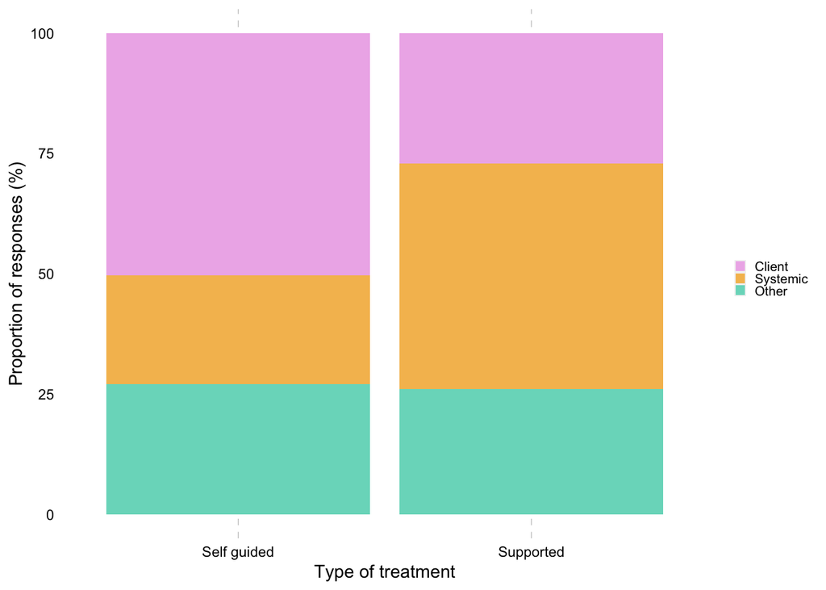

### *Plot reasons not received by source*

| source | Systemic | Client | Other | total |
| --- | --- | --- | --- | --- |
| Emergency mental health team | 300 | 146 | 111 | 557 |
| Existing mental health team | 597 | 210 | 225 | 1032 |
| GP | 712 | 299 | 353 | 1364 |
| Online talk therapy | 396 | 243 | 245 | 884 |
| NHS 111 | 90 | 76 | 44 | 210 |
| Non NHS phone | 168 | 247 | 125 | 540 |
| Government website | 159 | 389 | 195 | 743 |
| Non-government website | 139 | 347 | 184 | 670 |
| Online self-therapy | 96 | 195 | 105 | 396 |
| Structured therapeutic activity | 86 | 267 | 127 | 480 |

[output cut: 1 more lines]

| source | Systemic | Client | Other |
| --- | --- | --- | --- |
| Emergency mental health team | 53.85996 | 26.21185 | 19.92819 |
| Existing mental health team | 57.84884 | 20.34884 | 21.80233 |
| GP | 52.19941 | 21.92082 | 25.87977 |
| Online talk therapy | 44.79638 | 27.48869 | 27.71493 |
| NHS 111 | 42.85714 | 36.19048 | 20.95238 |
| Non NHS phone | 31.11111 | 45.74074 | 23.14815 |
| Government website | 21.39973 | 52.35532 | 26.24495 |
| Non-government website | 20.74627 | 51.79104 | 27.46269 |
| Online self-therapy | 24.24242 | 49.24242 | 26.51515 |
| Structured therapeutic activity | 17.91667 | 55.62500 | 26.45833 |

[output cut: 1 more lines]

[figure not shown]

**Client-level**

By sample

**Other**

By sample

#### For self guided options Systemic**

By sample

**Client-level**

By sample

**Other**

By sample

### Barriers by agency by wave

#### Supported

*Emergency mental health team*

By sample

*Existing mental health team*

By sample

*Online talk therapy*

By sample

*GP*

By sample

*NHS 111*

By sample

*Non NHS phone*

By sample

#### Self guided

*Government website*

By sample

*Non-government website*

By sample

*Online self-therapy*

By sample

*Structured therapeutic activity*

By sample

### Frequency of different levels of helpfulness by treatment type (supported/client led) by wave

**For supported options**

By sample

**For client led options**

By sample

### *Plot helpfulness*

|  | Self guided | Supported | labels |
| --- | --- | --- | --- |
| Extremely unhelpful | 1.663961 | 2.903843 | Extremely unhelpful |
| Very unhelpful | 2.394481 | 3.321162 | Very unhelpful |
| Somewhat unhelpful | 5.235390 | 6.259781 | Somewhat unhelpful |
| Neither helpful nor unhelpful | 11.850649 | 7.720396 | Neither helpful nor unhelpful |
| Somewhat helpful | 43.262987 | 28.690662 | Somewhat helpful |
| Very helpful | 23.620130 | 28.673274 | Very helpful |
| Extremely helpful | 11.972403 | 22.430882 | Extremely helpful |

```
[1] 78.85552
```

```
[1] 79.79482
```

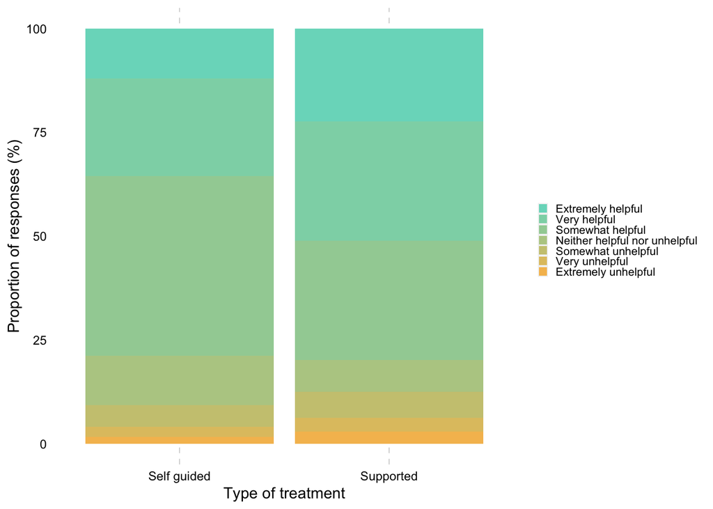

### Frequency of reasons for NOT seeking help

overall

## Gender stratification for barriers

Add gender to treatment data

```
Joining, by = c("ID", "Sample")
```

### Treatment seeking rates by Gender

```
[1] 1.802631e-176
```

```
    Pearson's Chi-squared test with Yates' continuity correction

data:  wide_tx_sought_mf[-1]
X-squared = 802.19, df = 1, p-value < 2.2e-16
```

| Gender | 0 | 1 | prop_sought | prop_not_sought |
| --- | --- | --- | --- | --- |
| Male | 17205 | 1544 | 8.235106 | 91.76489 |
| Female | 36516 | 7420 | 16.888201 | 83.11180 |

```
[1] 62685
```

### *Summary reasons not received - BY GENDER*

| reason | Self guided | Supported |
| --- | --- | --- |
| Systemic | 21.79065 | 46.83965 |
| Client | 51.87623 | 25.51564 |
| Other | 26.33311 | 27.64471 |

| reason | Self guided | Supported |
| --- | --- | --- |
| Systemic | 26.85185 | 48.05755 |
| Client | 47.83951 | 31.51079 |
| Other | 25.30864 | 20.43165 |

| reason | Self guided | Supported |
| --- | --- | --- |
| Systemic | 22.5 | 50.64935 |
| Client | 40.0 | 18.18182 |
| Other | 37.5 | 31.16883 |

### **Chi square test Gender by reasons for not receiving treatment**

```
[1] 7.61896e-05
```

```
    Pearson's Chi-squared test

data:  reasons_gender_supported[-1]
X-squared = 18.965, df = 2, p-value = 7.619e-05
```

```
[1] 3701
```

```
[1] 0.1371313
```

```
    Pearson's Chi-squared test

data:  reasons_gender_sg[-1]
X-squared = 3.9736, df = 2, p-value = 0.1371
```

```
[1] 1843
```

### **Plot Gender by reasons for not receiving treatment**

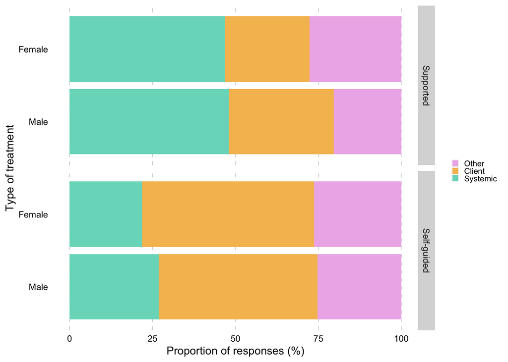

###**Chi square test Gender by Type of treatment sought**

```
[1] "prop_sought_supported_nbsd: "
```

```
[1] 70.08929
```

```
[1] "prop_sought_selfguided_nbsd: "
```

```
[1] 29.91071
```

```
    Pearson's Chi-squared test with Yates' continuity correction

data:  wide_tx_prop_mf[-1]
X-squared = 0.91275, df = 1, p-value = 0.3394
```

| Gender | Supported | Self guided | prop_supported | prop_selfguided |
| --- | --- | --- | --- | --- |
| Male | 1209 | 572 | 0.6788321 | 0.3211679 |
| Female | 5900 | 2948 | 0.6668174 | 0.3331826 |

```
[1] 10629
```

### **Plot Gender by Type of treatment sought**

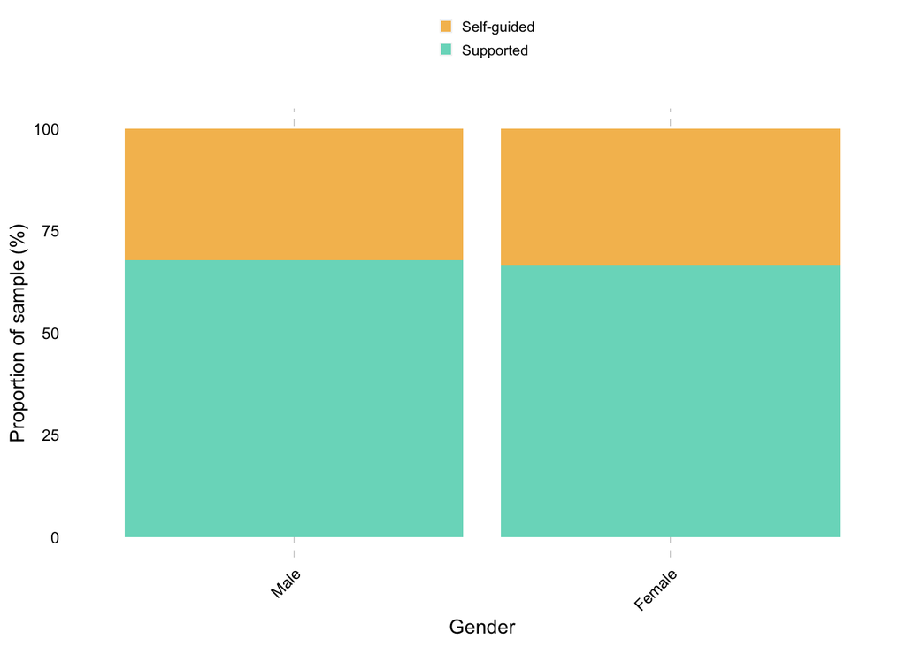

### **Chi square test Gender by Treatment seeking and gap**

```
[1] "Proportion of NB-SD gender seeking treatment: "
```

| sought | not_sought | prop_sought | prop_not_sought |
| --- | --- | --- | --- |
| 176 | 331 | 34.714 | 65.286 |

```
[1] "Proportion of NB-SD gender receiving treatment: "
```

| received | not_received | prop_received | prop_not_received |
| --- | --- | --- | --- |
| 149 | 27 | 84.65909 | 15.34091 |

```
[1] "Gender treatment seeking chisq: "
```

```
    Pearson's Chi-squared test with Yates' continuity correction

data:  treat_dat_seek_gender[-1]
X-squared = 802.19, df = 1, p-value < 2.2e-16
```

| Gender | n not sought | n sought | prop_sought | prop_not_sought |
| --- | --- | --- | --- | --- |
| Male | 17205 | 1544 | 0.08235106 | 0.9176489 |
| Female | 36516 | 7420 | 0.16888201 | 0.8311180 |

```
[1] "Gender treatment receipt chisq: "
```

```
    Pearson's Chi-squared test with Yates' continuity correction

data:  treat_dat_gap_gender[-1]
X-squared = 37.58, df = 1, p-value = 8.773e-10
```

| Gender | n received | n not received | prop_received | prop_not_received |
| --- | --- | --- | --- | --- |
| Male | 1201 | 343 | 0.7778497 | 0.2221503 |
| Female | 6251 | 1169 | 0.8424528 | 0.1575472 |

```
[1] 8964
```

### *Plot treatment seeking by gender*

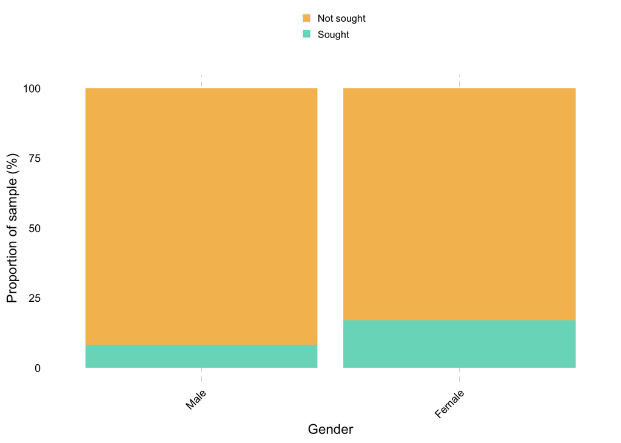

###*Plot treatment gap by gender*

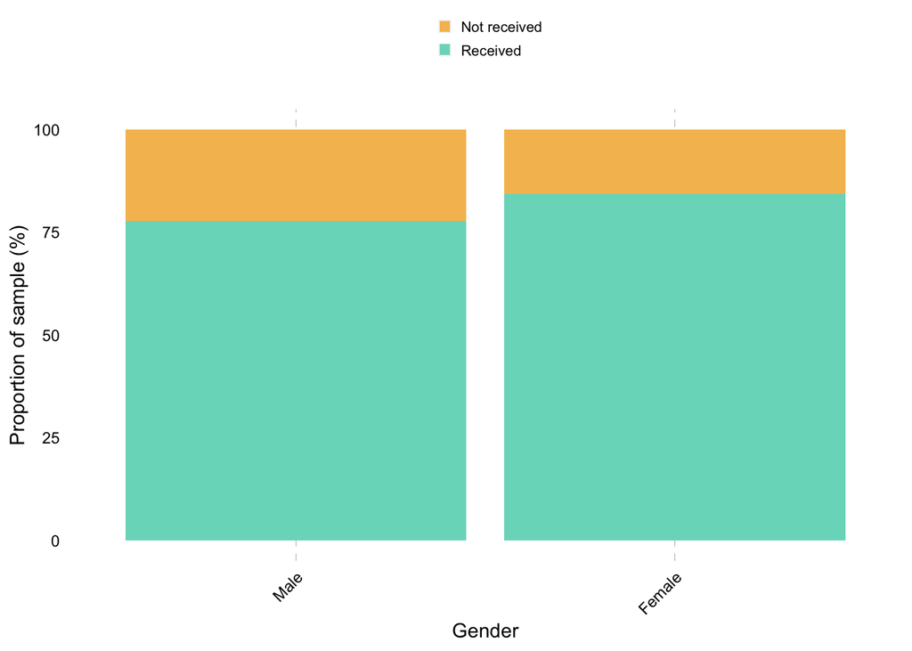

By sample

### **Ordinal logistic regression: tx_type*helpfulness**

```
Call:
polr(formula = labels ~ Type + n, data = long_helpfulness_freq,
    Hess = TRUE)

Coefficients:
                  Value Std. Error  t value
TypeSupported  0.017718  1.0170218  0.01742
n             -0.000038  0.0009093 -0.04179

Intercepts:
                                                  Value   Std. Error t value
Extremely helpful|Extremely unhelpful             -1.8058  0.9561    -1.8887
Extremely unhelpful|Neither helpful nor unhelpful -0.9312  0.8311    -1.1204
Neither helpful nor unhelpful|Somewhat helpful    -0.3053  0.8228    -0.3711
Somewhat helpful|Somewhat unhelpful                0.2693  0.8323     0.3235
Somewhat unhelpful|Very helpful                    0.8979  0.8681     1.0344
Very helpful|Very unhelpful                        1.7736  0.9934     1.7854

Residual Deviance: 54.48348
AIC: 70.48348
```

```
                                                          Value   Std. Error
TypeSupported                                      1.771811e-02 1.0170217945
n                                                 -3.800114e-05 0.0009093184
Extremely helpful|Extremely unhelpful             -1.805756e+00 0.9561077620
Extremely unhelpful|Neither helpful nor unhelpful -9.311596e-01 0.8311135953
Neither helpful nor unhelpful|Somewhat helpful    -3.053276e-01 0.8227968411
Somewhat helpful|Somewhat unhelpful                2.692819e-01 0.8323404511
Somewhat unhelpful|Very helpful                    8.978977e-01 0.8680536522
Very helpful|Very unhelpful                        1.773579e+00 0.9933608320
                                                      t value    p value
TypeSupported                                      0.01742156 0.98610031
n                                                 -0.04179080 0.96666547
Extremely helpful|Extremely unhelpful             -1.88865288 0.05893836
Extremely unhelpful|Neither helpful nor unhelpful -1.12037588 0.26255362
Neither helpful nor unhelpful|Somewhat helpful    -0.37108504 0.71057419
Somewhat helpful|Somewhat unhelpful                0.32352373 0.74629864
Somewhat unhelpful|Very helpful                    1.03438039 0.30095837
Very helpful|Very unhelpful                        1.78543293 0.07419112
```

```
                     2.5 %      97.5 %
TypeSupported -1.995853541 2.062376521
n             -0.001768295 0.001629431
```

### **Ordinal logistic regression: gender*helpfulness**

#### Effect of gender on helpfulness: self-guided interventions

```
Call:
polr(formula = labels ~ Gender + n, data = long_MF_helpful_self_guide,
    Hess = TRUE)

Coefficients:
               Value Std. Error t value
GenderMale 0.0737809   1.111040 0.06641
n          0.0002468   0.002057 0.11999

Intercepts:
                                                  Value   Std. Error t value
Extremely helpful|Extremely unhelpful             -1.7096  1.1176    -1.5297
Extremely unhelpful|Neither helpful nor unhelpful -0.8295  1.0340    -0.8022
Neither helpful nor unhelpful|Somewhat helpful    -0.1938  1.0488    -0.1848
Somewhat helpful|Somewhat unhelpful                0.3827  1.0559     0.3625
Somewhat unhelpful|Very helpful                    1.0089  1.0703     0.9426
Very helpful|Very unhelpful                        1.8821  1.1649     1.6157

Residual Deviance: 54.47014
AIC: 70.47014
```

```
                                                          Value Std. Error
GenderMale                                         0.0737808953  1.1110398
n                                                  0.0002467868  0.0020567
Extremely helpful|Extremely unhelpful             -1.7096338016  1.1176391
Extremely unhelpful|Neither helpful nor unhelpful -0.8294930039  1.0340387
Neither helpful nor unhelpful|Somewhat helpful    -0.1937827784  1.0487762
Somewhat helpful|Somewhat unhelpful                0.3827189363  1.0558718
Somewhat unhelpful|Very helpful                    1.0088885316  1.0703209
Very helpful|Very unhelpful                        1.8820727181  1.1648598
                                                      t value    p value
GenderMale                                         0.06640707 0.98610031
n                                                  0.11999165 0.96666547
Extremely helpful|Extremely unhelpful             -1.52968320 0.05893836
Extremely unhelpful|Neither helpful nor unhelpful -0.80218755 0.26255362
Neither helpful nor unhelpful|Somewhat helpful    -0.18477038 0.71057419
Somewhat helpful|Somewhat unhelpful                0.36246725 0.74629864
Somewhat unhelpful|Very helpful                    0.94260383 0.30095837
Very helpful|Very unhelpful                        1.61570751 0.07419112
```

```
                 2.5 %      97.5 %
GenderMale -2.14368524 2.273549530
n          -0.00384654 0.004429482
```

#### Effect of gender on helpfulness: supported interventions

```
Call:
polr(formula = labels ~ Gender + n, data = long_MF_helpful_supported,
    Hess = TRUE)

Coefficients:
                Value Std. Error  t value
GenderMale -0.1027924   1.182106 -0.08696
n          -0.0001695   0.001234 -0.13732

Intercepts:
                                                  Value   Std. Error t value
Extremely helpful|Extremely unhelpful             -1.9112  1.2364    -1.5458
Extremely unhelpful|Neither helpful nor unhelpful -1.0361  1.1362    -0.9119
Neither helpful nor unhelpful|Somewhat helpful    -0.4143  1.1438    -0.3622
Somewhat helpful|Somewhat unhelpful                0.1582  1.1589     0.1365
Somewhat unhelpful|Very helpful                    0.7852  1.1936     0.6578
Very helpful|Very unhelpful                        1.6604  1.2905     1.2866

Residual Deviance: 54.46466
AIC: 70.46466
```

```
                                                          Value  Std. Error
GenderMale                                        -0.1027923709 1.182106400
n                                                 -0.0001694959 0.001234323
Extremely helpful|Extremely unhelpful             -1.9112354122 1.236410206
Extremely unhelpful|Neither helpful nor unhelpful -1.0360811306 1.136174127
Neither helpful nor unhelpful|Somewhat helpful    -0.4143017166 1.143768405
Somewhat helpful|Somewhat unhelpful                0.1582287734 1.158870855
Somewhat unhelpful|Very helpful                    0.7851509212 1.193577278
Very helpful|Very unhelpful                        1.6604062466 1.290540749
                                                      t value    p value
GenderMale                                        -0.08695695 0.98610031
n                                                 -0.13731889 0.96666547
Extremely helpful|Extremely unhelpful             -1.54579395 0.05893836
Extremely unhelpful|Neither helpful nor unhelpful -0.91190347 0.26255362
Neither helpful nor unhelpful|Somewhat helpful    -0.36222518 0.71057419
Somewhat helpful|Somewhat unhelpful                0.13653702 0.74629864
Somewhat unhelpful|Very helpful                    0.65781323 0.30095837
Very helpful|Very unhelpful                        1.28659730 0.07419112
```

```
                 2.5 %      97.5 %
GenderMale -2.47527313 2.222711049
n          -0.00262749 0.002119763
```

#### **Effect of gender on helpfulness: plots**

### Reasons by gender

*Emergency mental health team*

By sample

*Existing mental health team*

By sample

*Online talk therapy*

By sample

*GP*

By sample

*NHS 111*

By sample

*Non NHS phone*

By sample

#### Self guided

*Government website*

By sample

*Non-government website*

By sample

*Online self-therapy*

By sample

*Structured therapeutic activity*

By sample

### Why not seek treatment by gender

### Frequency of different levels of helpfulness by treatment type (supported/client led) by wave by gender

**For supported options**

By sample

**For client led options**

By sample

## *Multi-panel plot*

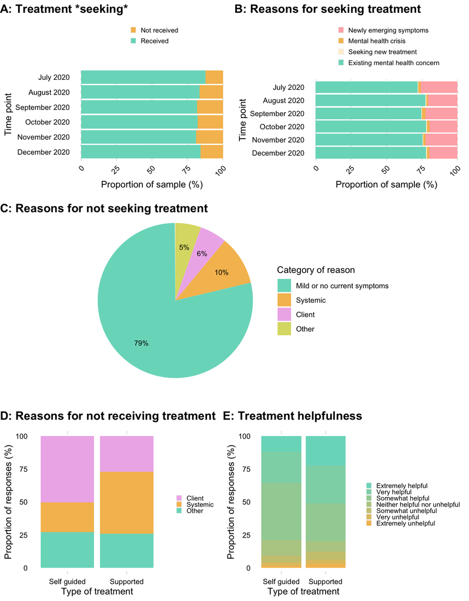

## *Gender multi-panel plot*

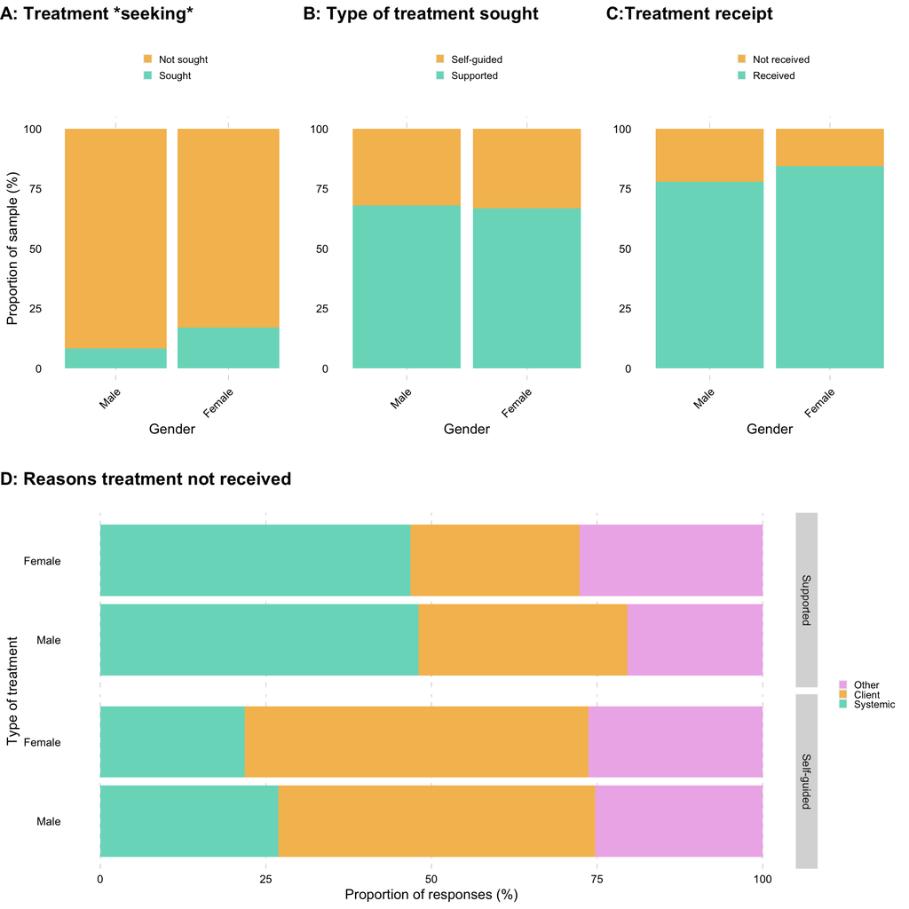

## Geographic

Project postcode data onto map of the UK. Use downloaded long/lat data mapped to postcodes from [this site](https://www.freemaptools.com/download-uk-postcode-lat-lng.htm) and city names from [here](https://www.doogal.co.uk/UKPostcodes.php).

### Create clean, labelled and flat outcode dataset

### Create counts of treatment seeking and barriers by region

#### read in map libraries

### Merge sample data to downloaded UK data

### create counts by county and district

check county data

check district data

## test building a UK map with districts plotted

## Seeking attempts by total responses maps

### Treatment seeking by county (no labels)

Size of the circles = total number of responses Colour of circles = percent of responses that indicated treatment seeking

### Treatment seeking by district (no labels)

Size of the circles = total number of responses Colour of circles = percent of responses that indicated treatment seeking

### Labelled the 5 counties ith greatest proporton seeking by total responses

#### county

#### district labelled with marker points for most percentage seek attempts by responses

orange markers for top 5 biggest gap, with labels

#### district labelled with marker points (no labels)

orange markers for top 5 biggest gap, WITHOUT labels

#### district - only top ten gap treatment seeking attemps

## Treatment gaps by total treatment seeking

### Treatment gap by county (no labels)

Size of the circles = total number of seeking attempts Colour of circles = percent of times treatment was not received when it was sought

### Treatment gap by district (no labels)

Size of the circles = total number of responses Colour of circles = percent of responses that indicated treatment gap

### Labelled the 5 counties ith greatest proporton gap by total responses

#### county

#### district labelled with marker points for most percentage seek attempts by responses

orange markers for top 5 biggest gap, with labels

#### district labelled with marker points (no labels)

orange markers for top 5 biggest gap, WITHOUT labels

#### district - only top ten gap treatment gap attemps

Filtered to districts where fewer than 5 seek attempts in the district

## Mapping alongside indices of multiple deprivation

used most recent in all cases (2019 for England and Wales, 2020 for Scotland, 2017 for Northern Ireland)

### Indices of multiple deprivation were downloaded from:

[England](https://opendatacommunities.org/resource?uri=http%3A%2F%2Fopendatacommunities.org%2Fdata%2Fsocietal-wellbeing%2Fimd2019%2Findices) [Ireland](https://www.nisra.gov.uk/publications/nimdm17-soa-level-results) [Scotland](https://www.gov.scot/publications/scottish-index-of-multiple-deprivation-2020v2-ranks/) *note: using the revised 2020 version for Scotland. See note on Website. Description of indicators is available on sheet 2 of excel downloaded from this link* [Wales](https://statswales.gov.wales/Catalogue/Community-Safety-and-Social-Inclusion/Welsh-Index-of-Multiple-Deprivation/WIMD-2019/localauthorityanalysis)

### Shapefiles for mapping districts were downloaded from:

[GB (excluding Ireland)](https://www.ordnancesurvey.co.uk/business-government/products/boundaryline) [IRE](https://www.opendatani.gov.uk/dataset/osni-open-data-largescale-boundaries-ni-outline1)

Projection of shapefiles converted to the Ordnance Survey Great Britain 1936 system (OSGB36 - EPSG code: 27700) to project into common space

### Notes

Using MDI rank for the time being - so ranks within each boundary will be comparable

## clean IMD data

## create shapefiles for maps with polygons for plotting district boundaries

## combine the IMD and shapefiles

## Plot IMD on map

### only IMD

### with treatmetn seeking

### with treatment gap

## Analytic decision notes

### Including cohort as a covariate

This would likely be a collider (sx severity is going to be associated with both cohort and treatment seeking)

#### NOTE TO SELF:: fix any treatment barrier stuff

#### make sure the counts are referring to the right thing!